# Data Visualization

## Aims

How to present data clearly

Introduce **ggplot2**

Graphs

- Scatterplots
- Histograms
- Boxplots
- Error bar charts
- Line graphs

## The Art of Presenting Data

**Graphs should (Tufte, 2001):**

Show the data

Induce the reader to think about the data being presented (rather than some other aspect of the graph)

Avoid distorting the data

Present many numbers with minimum ink

Make large data sets (assuming you have one) coherent

Encourage the reader to compare different pieces of data  
Reveal data

### Why Is This Graph Bad?

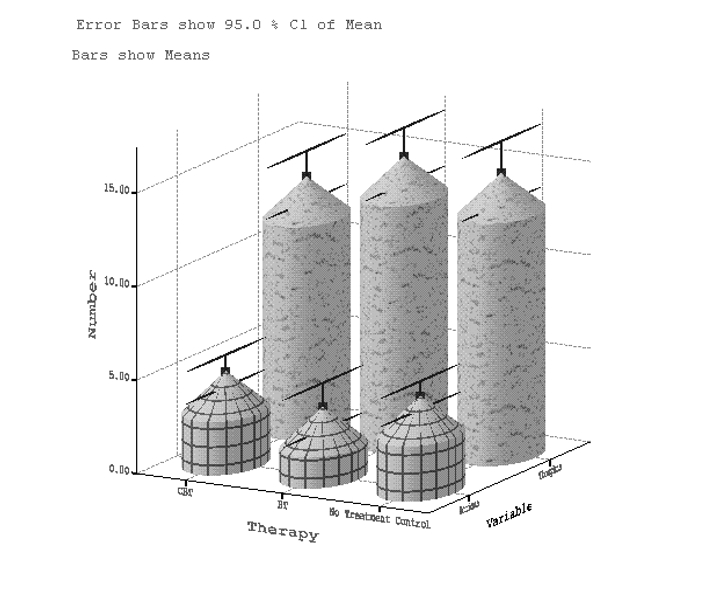

### Why Is This Graph Better?

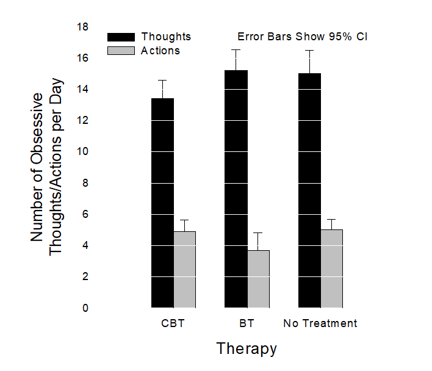

## Deceiving the Reader

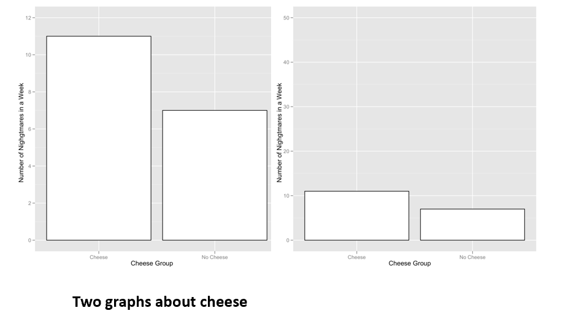

## ggplot2

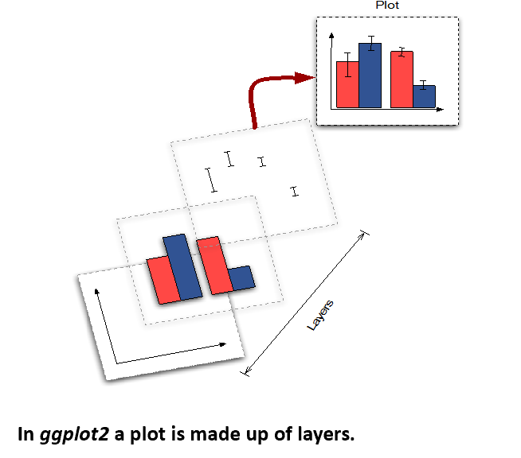

## Simple Scatterplot

First create your base graph, telling ggplot2 your variables and dataset.

```r
scatter <- ggplot(examData, aes(Anxiety, Exam))
```

Now we can add on. We want points (and will add a smoother):

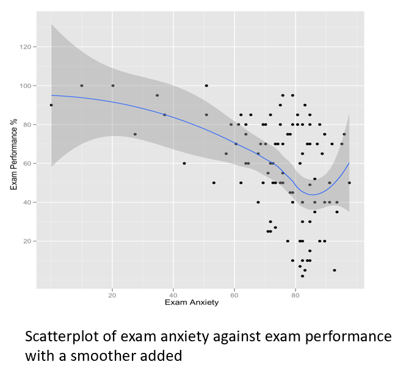

```r
scatter + geom_point() + geom_smooth() +
labs(x = "Exam Anxiety", y = "Exam Performance %")
```

## Simple Scatterplot With Regression Line

We will use the same *scatter* baseline plot object, and add onto it to add a regression line.

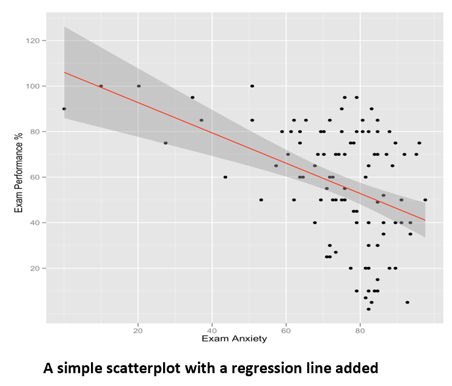

```r
scatter + geom_point() +
geom_smooth(method = "lm", colour = "Red") +
labs(x = "Exam Anxiety", y = "Exam Performance %")
```

## Grouped Scatterplot

Let’s say we also want to visualize the gender breakdown of anxiety and performance. We can add the *colour* argument to our *scatter* object:

```r
scatter <- ggplot(examData, aes(Anxiety, Exam, colour = Gender))
```

And we add Gender to our *fill* (to fill different colored lines/dots by gender) and to our *colour* label to create a legend:

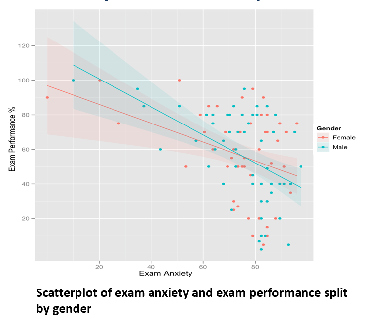

```r
scatter + geom_point() +
geom_smooth(method = "lm", aes(fill = Gender), alpha = 0.1) +
labs(x = "Exam Anxiety", y = "Exam Performance %", colour = "Gender")
```

## Histograms: Spotting Obvious Mistakes

Histograms plot:

- The score (x-axis)
- The frequency (y-axis)

Histograms help us to identify:

- The shape of the distribution
  - Skew
  - Kurtosis
  - Spread or variation in scores
- Unusual scores

## Histograms: Example

A biologist was worried about the potential health effects of music festivals

Went to Download Music Festival

Measured the hygiene of 810 concert-goers over the three days of the festival

Hygiene was measured using a standardized technique: Score ranged from 0 to 4

- 0 = you smell like a corpse rotting up a skunk’s bum
- 4 = you smell of sweet roses on a fresh spring day

### Histogram of Hygiene Scores for Day 1

Create the plot object:

```r
festivalHistogram <- ggplot(festivalData, aes(day1)) +
opts(legend.position = "none")
```

Add the graphical layer:

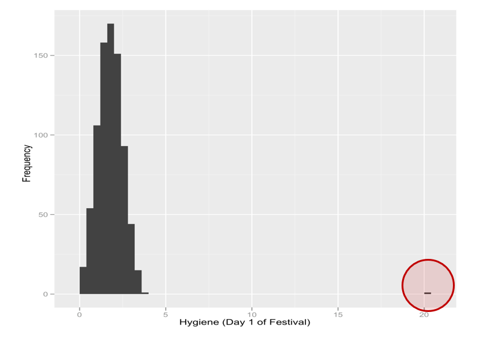

```r
festivalHistogram + geom_histogram(binwidth = 0.4) +
labs(x = "Hygiene (Day 1 of Festival)", y = "Frequency")
```

## Boxplots (Box-Whisker Diagrams)

Boxplots are made up of a box and two whiskers

The box shows:

- The median
- The upper and lower quartile
- The limits within which the middle 50% of scores lie

The whiskers show:

- The range of scores
- The limits within which the top and bottom 25% of scores lie

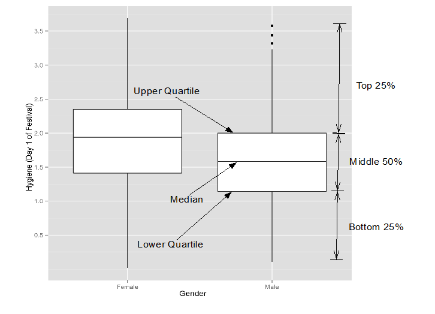